# Proyecto Final Trasplante UNIXR Github

Yessica Sánchez Ponce

11/18/2021

## **Introducción y Antecedentes**

Los herpesvirus beta y gama (VEB, CMV, HHV6, HHV7 y VSK) infectan de forma crónica desde la infancia, residiendo latentemente en células del sistema inmune, en donde alcanzarán un equilibrio con el hospedero que les permitirá permanecer de manera asintomática e indetectable, siempre que los portadores se mantenga inmunocompetentes. Sin embargo, ante eventos de inmunosupresión el equilibrio virus/hospedero puede romperse y desencadenar efectos patológicos graves. Por ejemplo, en los receptores de trasplante, debido al inmunocompromiso farmacológico al que son sometidos, la infección por estos herpesvirus puede tener una doble consecuencia: los efectos de la propia enfermedad infecciosa, que van desde cuadros febriles hasta linfomas o sarcomas y el efecto inmunomodulador, que contribuye al rechazo del injerto y favorece la coinfección de otros patógenos, incluyendo otros herpesvirus.

## **Pregunta**

**¿Qué características clínicas, herpes-virales e inmunes presentan los pacientes pediátricos sometidos a trasplante?**

## **Hipótesis**

**Debido a la inmunosupresió farmacológica a la que son sometidos los pacientes trasplantados, mostrarán cargas virales positivas a algunos herpesvirus y caracerísticas inmunes asociadas a patologías clínicas**

## **Objetivos**

1.- Conocer las características clínicas de los pacientes sometidos a trasplante de órgano sólido.  
2.- Determinar la frecuencia de infección de los herpesvirus beta y gama en los pacientes sometidos a trasplante de órgano sólido.  
3.- Determinar posibles asociaciones entre aspectos clínicos de los pacientes y moléculas inmunes como citocinas.

## **Métodos**

A las muestras colectadas se les determinó la carga viral de los herpesvirus beta y gama (VEB, CMV, HHV6, HHV7 y VSK) mediante una PCR múltiple. Se seleccionaron algunas de estas muestras analizadas de acuerdo a determinados críterios clínicos, para medir la concentración de 17 citocinas que participan en diferentes procesos inmunes.

Finalmete se construyo un data frame con todos las características clínicas, virales e inmunes analizadas en los pacientes sometidos a trasplante y sus muestras colectadas. El cual se utilizó pra realizar el análisis de dichas características haciendo uso del sistema operativo UNIX y del lenguaje de programación R, con Rstudio 4.1.1, usando paqueterías básicas como *base, datasets, dplyr y ggplot2*.

## **Diseño**

*Obtención y procesamiento de muestras biologicas* ———-  
*estandarización de PCR*———–  
*Determinación de carga viral*———-  
*Determinación de citocinas* ———–  
*Análisis en UNIX y R*

### **Análisis de datos R**

Revisar Proyecto_final_trasplante_R.Rmd  
Para ver el Markdown del análisis en R hacer clic aquí

### **Análisis de datos UNIX**

Revisar Proyecto_final_trasplante_UNIX.Rmd  
Para ver el Markdown del análisis en UNIX hacer clic aquí

## **Resultados**

**Características clínicas:**

- En total se analizaron 34 pacientes sometidos a traslplante de órgano sólido. 22 a trasplante renal “TR” y 12 a trasplante hepático “TH”.

```bash
cd /Users/yessicasanchezponce/Doctorado/cursos/UNIX_R/Proyecto_final_UNIXR_trasplante/Data
cut -f1  Data_Trasplante.txt |grep -v "^Paciente" | uniq |wc
cut -f1  Data_Trasplante.txt |grep "^TR" | uniq | wc
cut -f1  Data_Trasplante.txt |grep "^TH" | uniq | wc
```

```
##       34      34     155
##       22      22     102
##       12      12      53
```

- La edad de los paciente estuvo en un rango de 1 y hasta 17 años, con una mediana de 13 años.
- Se monitorearon desde el día -1 postrasplante, es decir, un día antes del trasplante y hasta 391 días posteriores al trasplante.
- Se analizaron en total 495 muestras de sangre periferica, con un rango de entre 4 y 18 muestras y una mediana de 15 muestras por paciente.
- Se observaron en total 18 eventos de rechazo de órgano.

```r
library(dplyr)
Data_trasplante<-read.table("/Users/yessicasanchezponce/Doctorado/cursos/UNIX_R/Proyecto_final_UNIXR_trasplante/Data/Data_Trasplante.txt",header = TRUE,sep = "\t",stringsAsFactors = FALSE)
Data_trasplante %>% count(Paciente) %>% summary()
```

```
##    Paciente               n
##  Length:34          Min.   : 4.00
##  Class :character   1st Qu.:15.00
##  Mode  :character   Median :15.00
##                     Mean   :14.56
##                     3rd Qu.:16.00
##                     Max.   :18.00
```

```r
Data_trasplante %>% select(Edad,Dias_postrasplante)%>% summary()
```

```
##       Edad       Dias_postrasplante
##  Min.   : 1.00   Min.   : -1.0
##  1st Qu.: 6.00   1st Qu.: 43.0
##  Median :13.00   Median :118.0
##  Mean   :11.14   Mean   :141.9
##  3rd Qu.:16.00   3rd Qu.:232.0
##  Max.   :17.00   Max.   :391.0
```

```r
Data_trasplante %>% select(Rechazo) %>% filter(Rechazo=="SI") %>% count()
```

```
##    n
## 1 18
```

**Dinámica de infección viral**

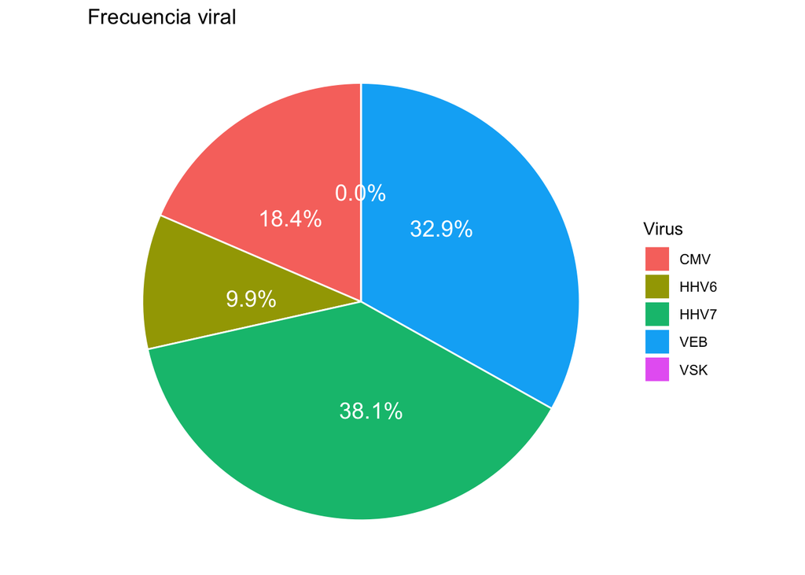

```r
Frecuencia2_virus <-data.frame(Virus=c("VEB","CMV","HHV6","HHV7","VSK"),Total=c(32.9,18.4,9.9,38.1,0))
library(ggplot2)
library(scales)
graf_pie_frec_virus<-ggplot(Frecuencia2_virus,aes(x="",y=Total, fill=Virus))+ geom_bar(stat = "identity",color="white")+ geom_text(aes(label=percent(Total/100)),position=position_stack(vjust=0.4),color="white",size=5)+ coord_polar(theta = "y")+ theme_void()+ labs(title="Frecuencia viral")
graf_pie_frec_virus
```

```r
Data_trasplante %>% select(leuVEB,leuCMV,leuHHV6,leuHHV7,leuVSK,pVEB,pCMV,pHHV6,pHHV7,pVSK)%>% summary()
```

```
##      leuVEB            leuCMV           leuHHV6           leuHHV7
##  Min.   :   0.00   Min.   :   0.00   Min.   :   0.00   Min.   :    0
##  1st Qu.:   0.00   1st Qu.:   0.00   1st Qu.:   0.00   1st Qu.:    0
##  Median :   0.00   Median :   0.00   Median :   0.00   Median :    0
##  Mean   :  40.12   Mean   :  85.44   Mean   :  26.48   Mean   :  223
##  3rd Qu.:   0.00   3rd Qu.:   0.00   3rd Qu.:   0.00   3rd Qu.:    0
##  Max.   :6010.00   Max.   :8530.00   Max.   :7170.00   Max.   :82470
##                    NA's   :1         NA's   :1         NA's   :1
##      leuVSK       pVEB               pCMV             pHHV6
##  Min.   :0   Min.   :     0.0   Min.   :    0.0   Min.   :      0
##  1st Qu.:0   1st Qu.:     0.0   1st Qu.:    0.0   1st Qu.:      0
##  Median :0   Median :     0.0   Median :    0.0   Median :      0
##  Mean   :0   Mean   :   671.3   Mean   :  203.5   Mean   :  12722
##  3rd Qu.:0   3rd Qu.:     0.0   3rd Qu.:    0.0   3rd Qu.:      0
##  Max.   :0   Max.   :260100.0   Max.   :36000.0   Max.   :3675240
##  NA's   :1
##      pHHV7             pVSK
##  Min.   :     0   Min.   :0
##  1st Qu.:     0   1st Qu.:0
##  Median :     0   Median :0
##  Mean   :  1872   Mean   :0
##  3rd Qu.:     0   3rd Qu.:0
##  Max.   :828360   Max.   :0
##
```

**Características inmunes**

```r
Data_trasplante %>% select(IL.1b,IL.2,IL.4,IL.5,IL.6,IL.7,IL.8,IL.10,IL.12,IL.13,IL.17,INF.g,MCP.1,MIP.1b,TNF.a,G.CSF,GM.CSF) %>% summary()
```

```
##      IL.1b             IL.2             IL.4             IL.5
##  Min.   :0.0000   Min.   : 0.000   Min.   :0.0000   Min.   :0.0000
##  1st Qu.:0.0000   1st Qu.: 0.000   1st Qu.:0.0000   1st Qu.:0.0000
##  Median :0.0250   Median : 0.000   Median :0.0000   Median :0.0000
##  Mean   :0.2289   Mean   : 1.102   Mean   :0.1151   Mean   :0.1232
##  3rd Qu.:0.1675   3rd Qu.: 1.010   3rd Qu.:0.0400   3rd Qu.:0.0000
##  Max.   :9.6700   Max.   :37.770   Max.   :4.2500   Max.   :4.9700
##  NA's   :337      NA's   :337      NA's   :337      NA's   :337
##       IL.6             IL.7             IL.8            IL.10
##  Min.   : 0.000   Min.   : 0.000   Min.   : 0.000   Min.   : 0.0000
##  1st Qu.: 0.000   1st Qu.: 0.000   1st Qu.: 0.070   1st Qu.: 0.0000
##  Median : 0.150   Median : 1.350   Median : 1.835   Median : 0.0000
##  Mean   : 1.910   Mean   : 3.041   Mean   : 6.824   Mean   : 0.9516
##  3rd Qu.: 1.065   3rd Qu.: 3.643   3rd Qu.: 4.497   3rd Qu.: 0.0000
##  Max.   :82.510   Max.   :47.470   Max.   :99.110   Max.   :26.5200
##  NA's   :337      NA's   :337      NA's   :337      NA's   :337
##      IL.12             IL.13            IL.17             INF.g
##  Min.   :  0.000   Min.   :0.0000   Min.   : 0.0000   Min.   :0.0000
##  1st Qu.:  0.000   1st Qu.:0.1500   1st Qu.: 0.0425   1st Qu.:0.0400
##  Median :  0.000   Median :0.3400   Median : 0.8500   Median :0.4100
##  Mean   :  4.728   Mean   :0.5996   Mean   : 1.4130   Mean   :0.6638
##  3rd Qu.:  2.630   3rd Qu.:0.7500   3rd Qu.: 1.6300   3rd Qu.:0.8425
##  Max.   :154.240   Max.   :6.2500   Max.   :29.5000   Max.   :8.8300
##  NA's   :337       NA's   :337      NA's   :337       NA's   :337
##      MCP.1            MIP.1b            TNF.a            G.CSF
##  Min.   : 0.000   Min.   :  0.000   Min.   : 0.770   Min.   :  0.000
##  1st Qu.: 3.615   1st Qu.:  2.160   1st Qu.: 2.792   1st Qu.:  0.000
##  Median : 7.690   Median :  3.505   Median : 5.170   Median :  0.000
##  Mean   : 9.798   Mean   :  6.515   Mean   : 6.535   Mean   :  6.146
##  3rd Qu.:13.062   3rd Qu.:  6.277   3rd Qu.: 8.807   3rd Qu.:  0.000
##  Max.   :55.130   Max.   :124.250   Max.   :31.750   Max.   :211.310
##  NA's   :337      NA's   :337       NA's   :337      NA's   :337
##      GM.CSF
##  Min.   :0.0000
##  1st Qu.:0.0000
##  Median :0.0000
##  Mean   :0.0629
##  3rd Qu.:0.0000
##  Max.   :7.3200
##  NA's   :337
```

```r
Data_trasplante %>% select(Muestra,IL.10) %>% subset(IL.10>0) %>% count()
```

```
##    n
## 1 35
```

```r
IL10.orden <- Data_trasplante %>% select(Muestra,IL.10) %>% subset(IL.10>0)
IL10.orden <- IL10.orden[order(IL10.orden$IL.10),]
IL10.orden
```

```
##     Muestra IL.10
## 39    TR5.2  0.01
## 2     TR1.1  0.03
## 183  TR14.8  0.03
## 201 TR15.11  0.03
## 41    TR5.4  0.08
## 190  TR15.0  0.23
## 221  TR17.1  0.24
## 197  TR15.7  0.31
## 43    TR5.6  0.73
## 119  TR10.3  1.19
## 398   TH7.5  1.19
## 160  TR13.1  1.37
## 205  TR16.0  1.44
## 212  TR16.7  1.44
```

[output cut: 21 more lines]

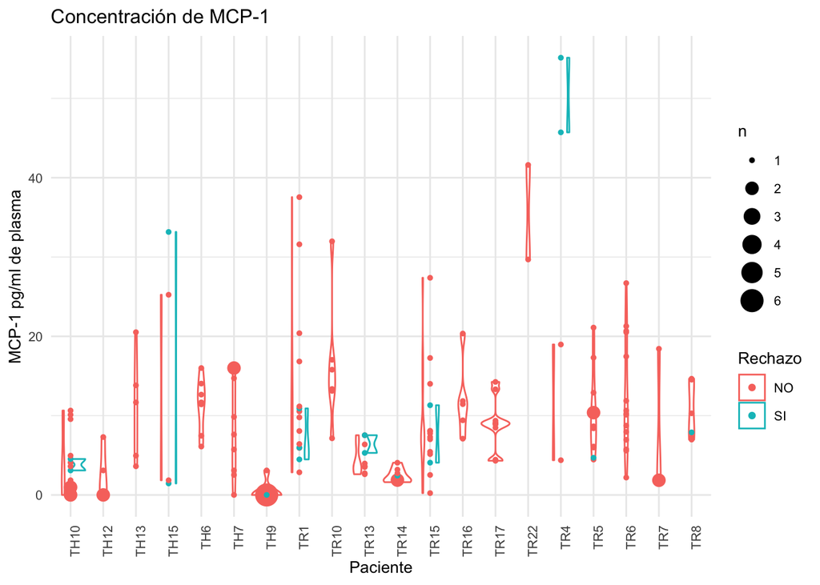

```r
Conc.MCP1<-Data_trasplante %>% select(Paciente,Rechazo,MCP.1) %>% subset(MCP.1>=0)
graf_viol_MCP1_rechazo <- ggplot(Conc.MCP1,aes(Paciente,MCP.1,color=Rechazo)) + geom_violin() +geom_count() + theme_minimal() + labs(x="Paciente",y="MCP-1 pg/ml de plasma",title = "Concentración de MCP-1") + theme(text = element_text(size=10),axis.text.x = element_text(angle=90, hjust=1))
graf_viol_MCP1_rechazo
```

## **Conclusiones**

La inmunosupresión farmacológica a la que son sometidos los pacientes trasplantados, permité la primo-infección o reactivación de los herpesvirus beta y gama en los pacientes sometidos a trasplante renal. Ya que, se observaron 152 muestras positivas a estos agentes virales. La presencia de estos herpesvirus puede modular la respuesta inmune, influyendo en los eventos de Rechazo, como se observó en el análisis de la citocina MCP-1, en donde las mayores concentraciones observadas en plasma coincidieron con los eventos de rechazo. Sin embargo, se requieren muchos más análisis que respalden estás observaciones.

Para ver el contenido de los archivos de cada carpeta:  
**Carpeta Data**  
Para ver el Data original .xlsx del análisis hacer clic aquí  
Para ver el Data .txt hacer clic aquí

**Carpeta Resultados** Los archivos de Frecuencias virales y citocinas:  
.RData data aquí  
aquí  
.RData plot aquí  
aquí  
.txt aquí  
aquí  
plot .png aquí  
aquí